# Lead Exposure and IQ

Adarsh SharmaD

2026-09-20

## Background

For this report, we compare IQ scores between children who lived near a lead-emitting ore smelter and those who lived farther away. The dataset includes and observation of 124 children between the ages of 3 and 15 in El Paso, Texas. Location is recorded as Near for children who lived within one mile of the smelter and Far for those who lived farther away. IQ was measured using the Wechsler Intelligence Scale for Children. Although we are comparing IQ by location, the original study compared children with high and low lead levels. Any differences observed here describe the two location groups and do not establish that living near the smelter caused a difference in IQ.

## Data Import and inspect

```r
lead <- read.csv("../DataRaw/lead-iq-01.csv")

names(lead)
```

```
## [1] "Smelter" "IQ"
```

```r
head(lead)
```

```
##   Smelter IQ
## 1     Far 70
## 2     Far 85
## 3     Far 86
## 4     Far 76
## 5     Far 96
## 6     Far 94
```

```r
str(lead)
```

```
## 'data.frame':    124 obs. of  2 variables:
##  $ Smelter: chr  "Far" "Far" "Far" "Far" ...
##  $ IQ     : int  70 85 86 76 96 94 115 97 128 999 ...
```

```r
lead$IQ[lead$IQ == 999] <- 99
```

## IQ Levels by Location

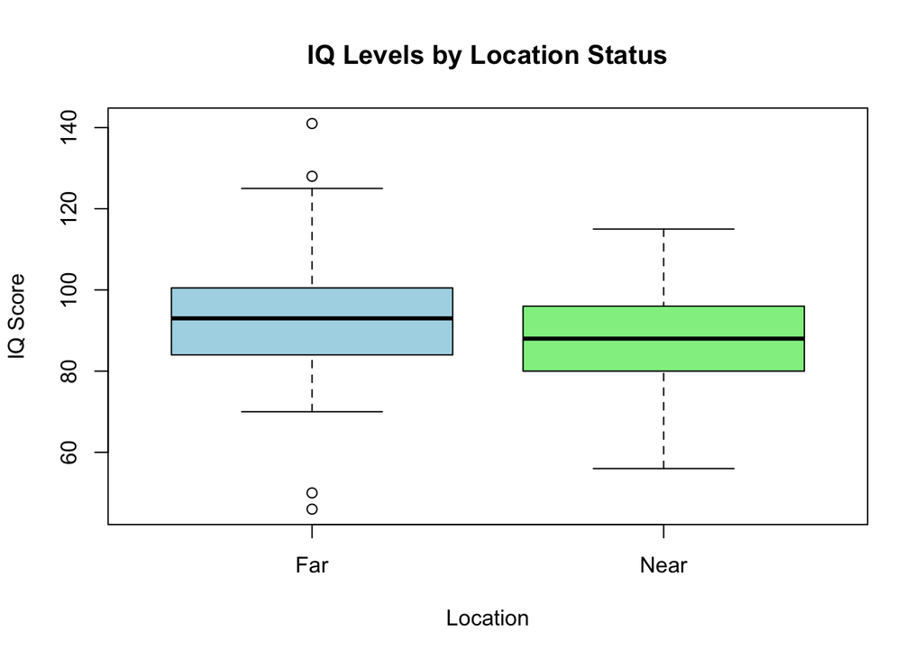

```r
boxplot(IQ ~ Smelter,
   data = lead,
   main = "IQ Levels by Location Status",
   xlab = "Location", ylab = "IQ Score",
   col = c("lightblue", "lightgreen"))
```

The boxplot compares IQ scores between children who lived near the smelter and those who lived farther away. The Far group has a higher median IQ.

## Summary Table of IQ Scores

```r
iq_summary <- t(sapply(
  split(lead$IQ, lead$Smelter),
  function(x) c(N = length(x), Mean = mean(x),
                SD = sd(x), Median = median(x))
))

knitr::kable(iq_summary, digits = 2,
             caption = "IQ scores by location status")
```

IQ scores by location status

|  | N | Mean | SD | Median |
| --- | --- | --- | --- | --- |
| Far | 67 | 92.69 | 15.97 | 93 |
| Near | 57 | 89.19 | 12.17 | 88 |

The table summarizes the number of children, mean, standard deviation, and median IQ for each location group. The mean IQ was 92.69 in the Far group and 89.19 in the Near group.